# Stat 436 Homework-4

Peiyuan Li

2024-04-27

```r
# Set global chunk options to suppress warnings and messages for a cleaner output
knitr::opts_chunk$set(warnings = FALSE, message = FALSE)

# Load necessary libraries for data manipulation, visualization, and modeling
library(dplyr)
library(tidyverse)
```

```r
library(ggplot2)
library(tidymodels)
library(broom)
library(tidytext)
# Read the diamonds dataset from github raw
diamonds_df <- read_csv("https://raw.githubusercontent.com/pli233/Working/main/Stat436/Homework4%20MODEL%20VISUALIZATION/diamonds.csv")
```

Since PCA requires numerical data, all categorical labels in the dataset are converted to corresponding numerical levels in the preprocessing step.

```r
# Convert the categorical attributes 'cut', 'clarity', and 'color' into numerical levels
diamonds_df <- diamonds_df %>%
  mutate(
    cut = recode(cut,
                 "Ideal" = 5,
                 "Premium" = 4,
                 "Very Good" = 3,
                 "Good" = 2,
                 "Fair" = 1),
    clarity = recode(clarity,
                     "I1" = 1,
                     "SI2" = 2,
                     "SI1" = 3,
                     "VS2" = 4,
                     "VS1" = 5,
                     "VVS2" = 6,
                     "VVS1" = 7,
                     "IF" = 8),
    color = recode(color,
                   "J" = 1,
                   "I" = 2,
                   "H" = 3,
                   "G" = 4,
                   "F" = 5,
                   "E" = 6,
                   "D" = 7)
  )

# Check the first few rows to confirm the changes
head(diamonds_df)
```

| carat | cut | color | clarity | depth | table | price | x | y | z |
| --- | --- | --- | --- | --- | --- | --- | --- | --- | --- |
| 0.23 | 5 | 6 | 2 | 61.5 | 55 | 326 | 3.95 | 3.98 | 2.43 |
| 0.21 | 4 | 6 | 3 | 59.8 | 61 | 326 | 3.89 | 3.84 | 2.31 |
| 0.23 | 2 | 6 | 5 | 56.9 | 65 | 327 | 4.05 | 4.07 | 2.31 |
| 0.29 | 4 | 2 | 4 | 62.4 | 58 | 334 | 4.20 | 4.23 | 2.63 |
| 0.31 | 2 | 1 | 2 | 63.3 | 58 | 335 | 4.34 | 4.35 | 2.75 |
| 0.24 | 3 | 1 | 6 | 62.8 | 57 | 336 | 3.94 | 3.96 | 2.48 |

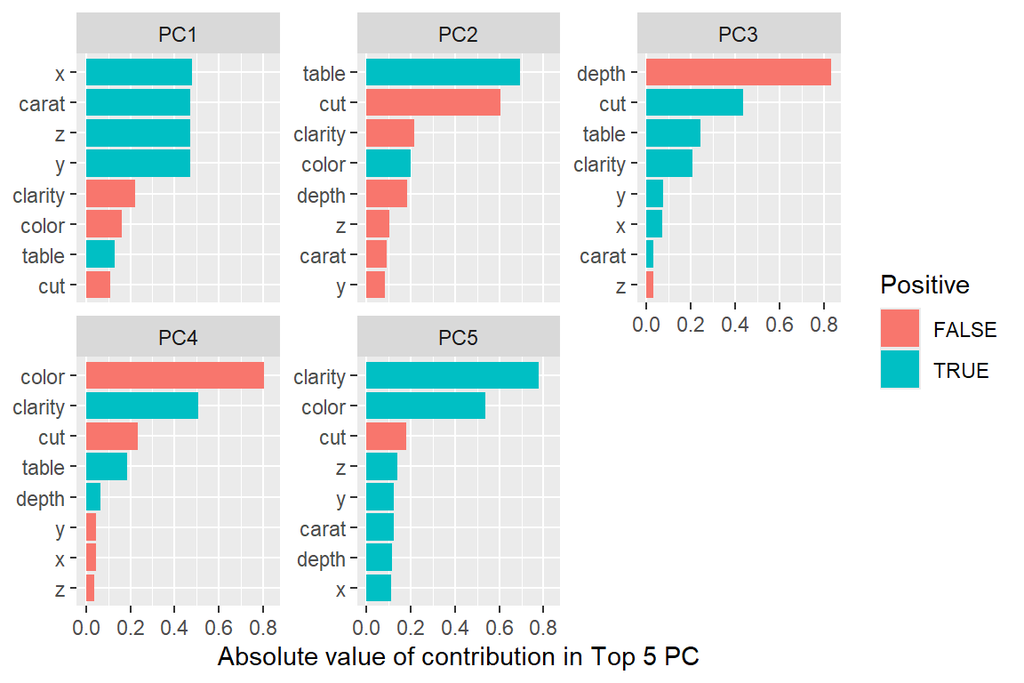

```r
# Select all variables except 'price' for PCA
temp <- diamonds_df %>%  select(-price)

# Define the recipe for PCA with normalization and threshold for variance explained
pca_recipe <- recipe(~ ., data = temp) %>%
  step_normalize(all_numeric(), -all_outcomes()) %>%
  step_pca(all_numeric(), -all_outcomes(), threshold = 0.95)

# Prepare and bake the recipe
pca_prep <- prep(pca_recipe)

# Tidy the PCA results to extract component variances and loadings
tidied_pca <- tidy(pca_prep, 2)

# Plot the contributions of elements in the top 5 PCA components
tidied_pca %>%
  filter(component %in% paste0("PC", 1:5)) %>%
  group_by(component) %>%
  slice_max(order_by = abs(value), n = 8) %>%
  ungroup() %>%
  mutate(terms = reorder_within(terms, abs(value), component)) %>%
  ggplot(aes(abs(value), terms, fill = value > 0)) +
  geom_col() +
  facet_wrap(~component, scales = "free_y") +
  scale_y_reordered() +
  labs(
    x = "Absolute value of contribution in Top 5 PC",
    y = NULL, fill = "Positive"
  )
```

After performing PCA on the dataset, we visualize the results to see the contribution of each element in the top 5 PCA components.

We observe that ‘x’, ‘y’, ‘z’, and ‘carat’ have similar and significant contributions in PC1, suggesting a correlation among them.

In PC2, ‘table’ and ‘cut’ show higher loadings, and in PC3, ‘depth’ and ‘cut’ are prominent, indicating possible relationships between these attributes.

PC4 and PC5 highlight strong loadings for ‘color’ and ‘clarity’, underlining their importance and interrelation in these components.

From each PC, the strongest contributors—‘carat’, ‘table’, ‘depth’, ‘color’, and ‘clarity’—are selected to construct a linear model to predict diamond prices.

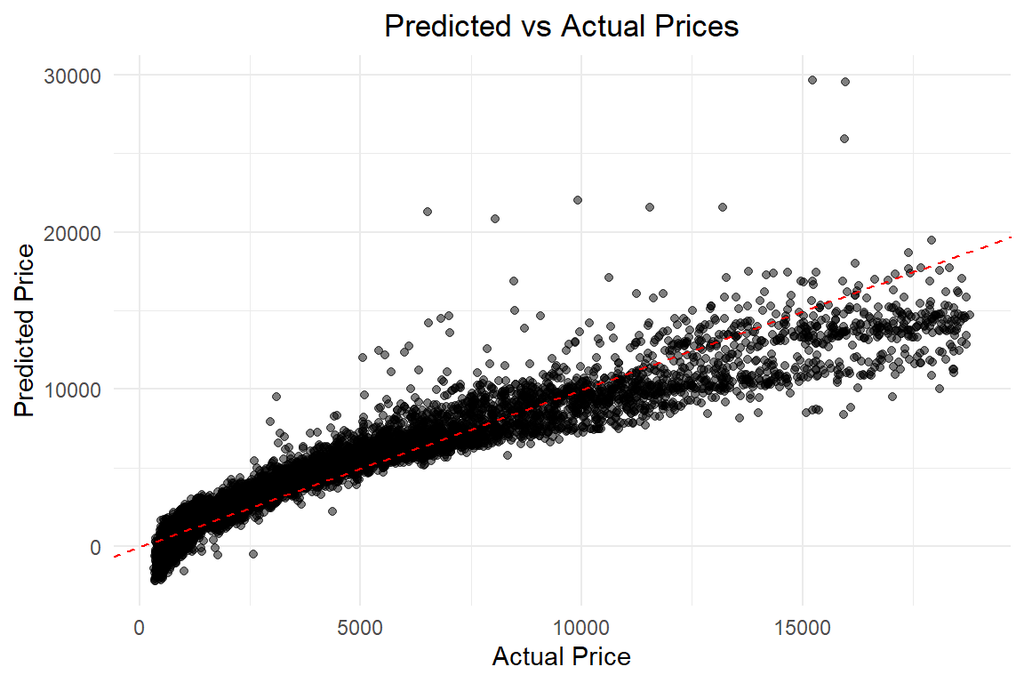

```r
# Split the dataset into training and testing sets for model evaluation
set.seed(123)  # Set a seed for reproducibility
split_data <- initial_split(diamonds_df, prop = 0.8, strata = "price")
train_data <- training(split_data)
test_data <- testing(split_data)

# Build a linear regression model using the identified predictors
lm_model <- lm(price ~ carat + table + depth + color + clarity, data = train_data)

# Predict prices on the test set
test_predictions <- predict(lm_model, newdata = test_data)

# Combine predictions with the actual test data
test_data <- test_data %>%
  mutate(predicted_price = test_predictions)

# Visualize the predicted vs. actual prices with a centered title
ggplot(test_data, aes(x = price, y = predicted_price)) +
  geom_point(alpha = 0.5) +
  geom_abline(color = "red", linetype = "dashed") +
  labs(x = "Actual Price", y = "Predicted Price", title = "Predicted vs Actual Prices") +
  theme_minimal() +
  theme(plot.title = element_text(hjust = 0.5))  # Center the plot title
```